# Homework1

İlayda Tutal - IE360 - Fall 2020

08 11 2020

# Data Visualization of Three Measures From Turkey and Comparing with Google Trends Data

When I started doing research to find an interesting data set, my dad said that he wonders about gasoline prices and how drastically they have changed. So, I thought it would be a good data to start with. I took the xlsx file from [VeriKaynagi](https://www.verikaynagi.com/grafik/yillara-gore-ortalama-benzin-fiyati-2009-2020/). This data set consists of monthly average prices of gasoline over the years 2009-2020. Since there were only three-month data in 2020, I didn’t include 2020 and I wanted to show the last 5 year’s change especially.

After I took my data, I did necessary manipulations such as collect them in one data frame to have a tidier data set.

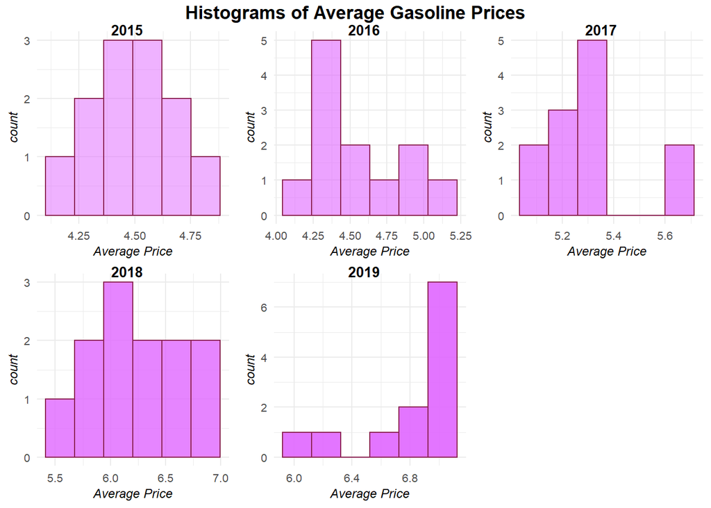

And the box plot of the gasoline prices:

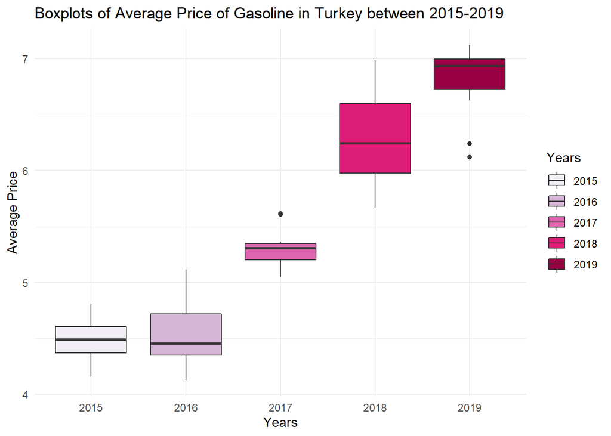

It can be seen that in the last 2-3 years, there is a significant increase in the prices.

Since the price of gasoline is important for a lot of people in Turkey, it was time to see the relation between the search keyword “benzine zam (raise in gasoline price)”. So, Google Trends data is collected. The search volume of the first 3 years has quite a similarity. On the other hand, we can see an increase in the search volume in 2019 which was expected when the histograms are observed.

[figure not shown]

The keyword “benzine zam” seems positively correlated. This is quite logical considering that usually people hear about the increase in gasoline prices and serach up on Google to learn the details.

## 2) Monthly Rent Paid by Tenants In Turkey Over 2009-2019

We all know there is a constant increase in the rent prices but I wonder how this increase changed over time. The data was taken from [VeriKaynagi](https://www.verikaynagi.com/grafik/yillara-gore-kiraci-tarafindan-odenen-gercek-kira-bedeli-2009-2019/) again. The data shows the actual monthly average rent paid by tenants over 2009 - 2019.

I used *ggplot2* library to plot my histograms and box plots. When I plotted the histograms of rent paid by tenants, actually there was not a huge difference between yearly histograms. However, there was a noticeable increase in the prices which can be seen in x axis of the histograms. This made me think there is seasonality and this was quite logical as leases are renewed once a year. Therefore I wondered if there is also a seasonality in Google Trends or not.

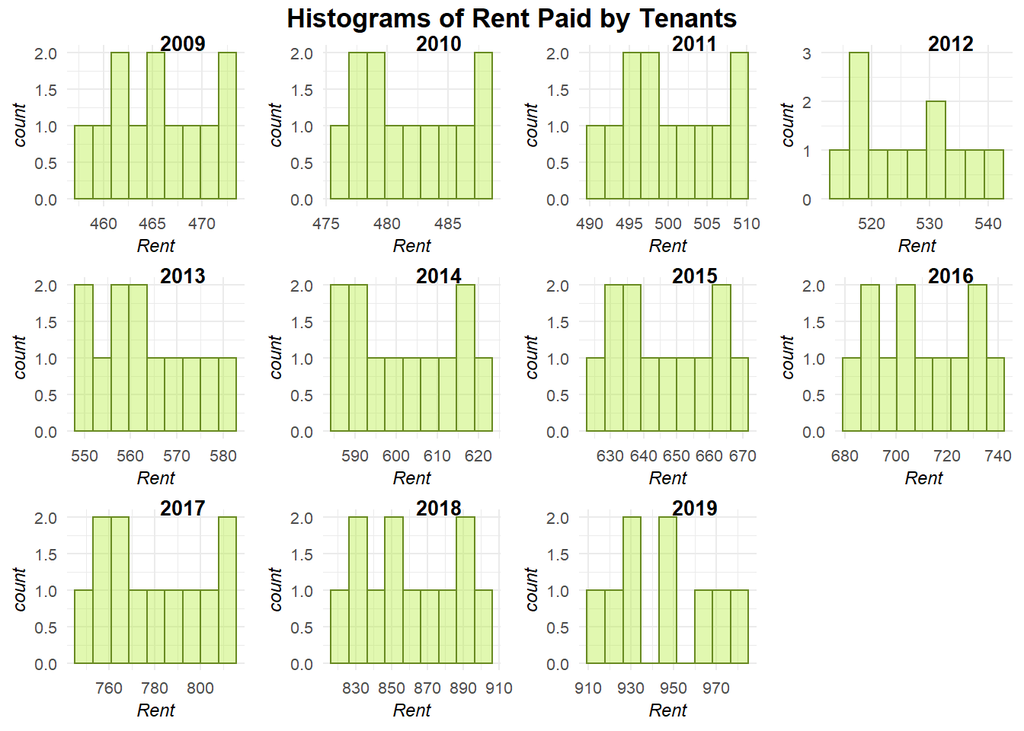

Also the boxplots of rents paid by tenants over years:

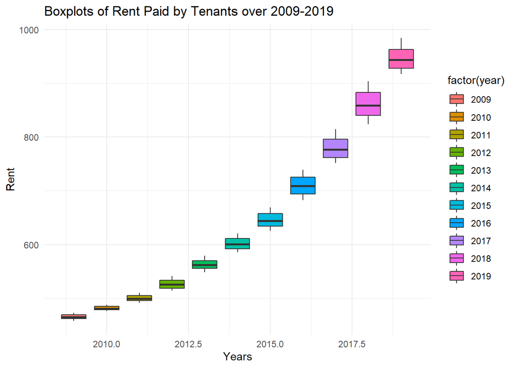

It can be seen above that the shape of the box plots look very close as they’re expected. So, I get the search volume data of “kiralik daire” (apartment for rent) to see if there is a seasonality and more to explore. This is the line plot of the search volume. This line plot clearly shows that there is a pattern that repeats over time :

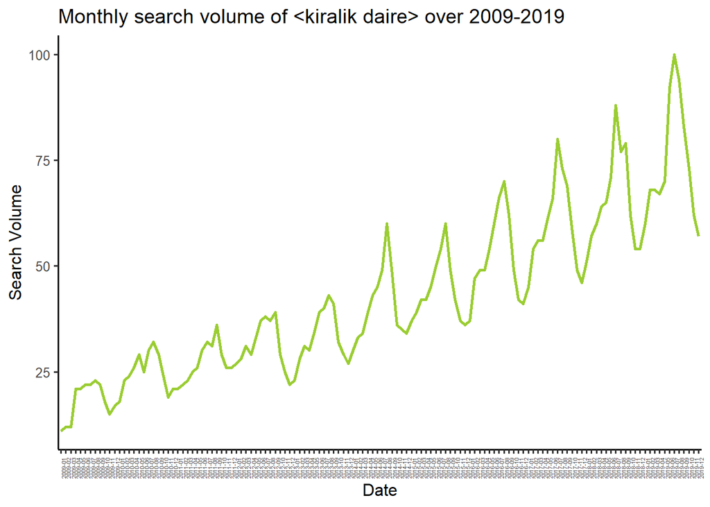

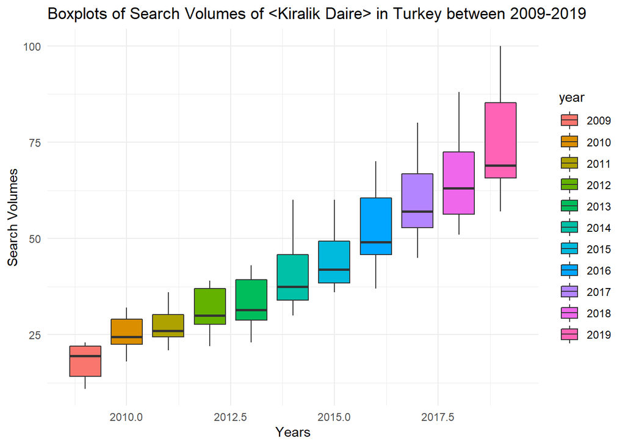

## 3) Number of Visitors Resident in Abroad Who Visit Turkey Over 2012-2019

The third data consists the number of visitors resident in abroad who visit Turkey over 2012-2019, their average expenditure as dollars. But in this part, I took only the number of visitors column. This time, I took the data from [TUIK](https://data.tuik.gov.tr/) website.

Especially the first four histograms are very similar. There is a change in year 2016, and there are similarities to 2016 in the following years. There might be different reasons what affected these values but what I wonder was the Google Trends data from this point on.

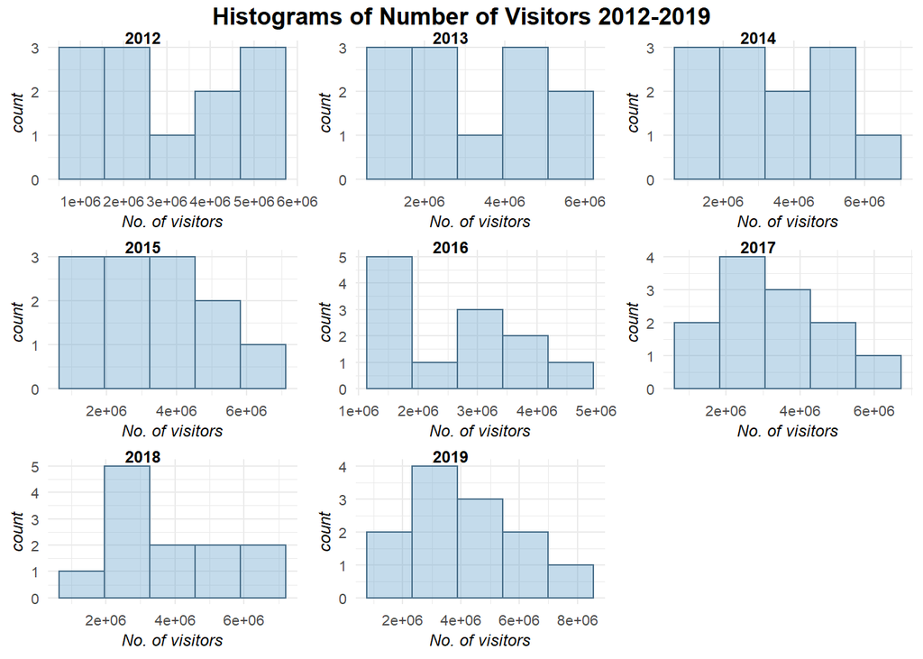

Box plots of number of visitors can be seen below:

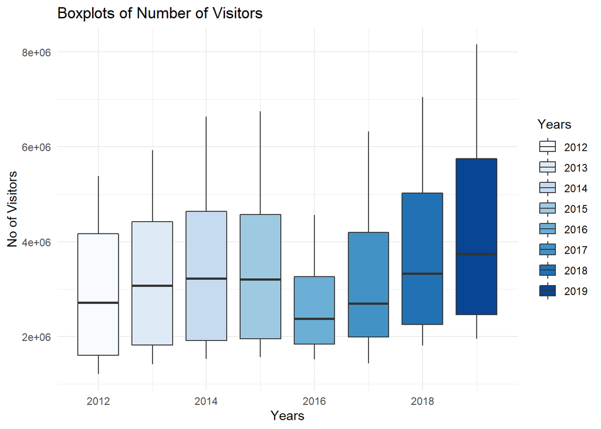

Since these people are resident in abroad, I assume they might need to find a hotel. It seems more meaningful to decide the keyword as “hotels in Istanbul” rather than “hotels in Turkey”. Because hotels in Turkey woud be too comprehensive. Box plots of the search volume can be seen below:

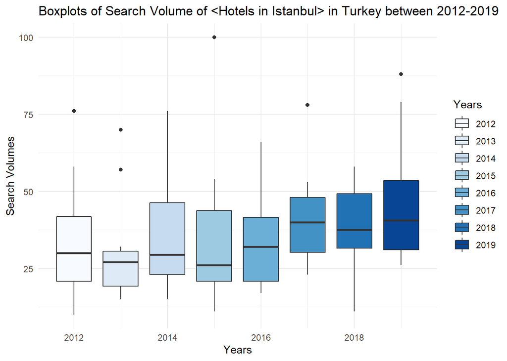

The keyword “hotels in Istanbul” seems positively correlated especially after 2016. There is a decrease in 2016 and a gradual increase in the next three years. Since not all the visitors come to Istanbul or stay in an hotel, these two data are not perfectly correlated. But, tourists who come to Istanbul and stay in an hotel correspond to the majority; so, there is still a correlation.

**For the rmd file and codes of this report [click](https://bu-ie-360.github.io/fall20-ilaydatutal/files/Homework1.Rmd)**

**References:**

- [TUIK](https://data.tuik.gov.tr/)
- [VeriKaynagi](https://www.verikaynagi.com/)
- [Quick-R by datacamp](https://www.statmethods.net/index.html)
- [STHDA](http://www.sthda.com/english/)